# Bee analysis test

Eddy Dowle

2025-05-15

## Geomorph

Using Geomorph package to do a generalized procrustes analysis on the TPS file and run basic statistics/plots. Not very familiar with the package so Im only using a very small subset of it and Im not convinced that I have everything correct/done in the best way (its been 15 years since I did this).

```r
#bring in TPS file
bees<-readland.tps('C:/Users/hrlexd/Dropbox/PlantAndFood (1)/NativeBees/Bee_pictures/Forewings_19_05_2025_29_05_25merged_ejd.TPS',specID = 'imageID',negNA = TRUE)
```

```
##
## No curves detected; all points appear to be fixed landmarks.
```

```r
#col_bees<-read.csv('C:/Users/hrlexd/Dropbox/PlantAndFood (1)/NativeBees/Bee_pictures/bee_colours.csv')
#generate a file of species names for each sample etc for plotting
Sample_names<-labels(bees)[[3]]
#Sample_names<-gsub('.*\\\\','',Sample_names)
species_list<-gsub('_.*','',Sample_names)
#species_list<-gsub('L.Kanap','L.kanap',species_list)
unique(species_list)
```

```
##  [1] "L.bolt"    "L.mont"    "L.fulv"    "L.huak"    "L.imat"    "L.kanap"
##  [7] "L.paahua"  "L.pango"   "Vest"      "L.hudsoni" "L.hukare"  "L.keehua"
## [13] "L.marit"   "L.metal"   "L.pekanui" "L.purp"    "L.unknown" "L.waipou"
```

```r
species_list_barry<-gsub('_[0-9].*','',Sample_names)
unique(species_list_barry)
```

```
##  [1] "L.bolt"          "L.mont"          "L.fulv"          "L.huak"
##  [5] "L.imat"          "L.kanap"         "L.paahua"        "L.pango"
##  [9] "Vest"            "L.bolt_Barry"    "L.hudsoni_Barry" "L.hukare_Barry"
## [13] "L.keehua_Barry"  "L.marit_Barry"   "L.metal"         "L.pango_Barry"
## [17] "L.pekanui_Barry" "L.purp_Barry"    "L.unknown"       "L.waipou_Barry"
```

```r
#estimate missing
bees<-estimate.missing(bees, method = "TPS")
#do a generalixed procrustes analysis on TPS
beesgpa<-gpagen(bees)
```

```
##
## Performing GPA
##   |                                                                              |                                                                      |   0%  |                                                                              |==================                                       …
##
## Making projections... Finished!
```

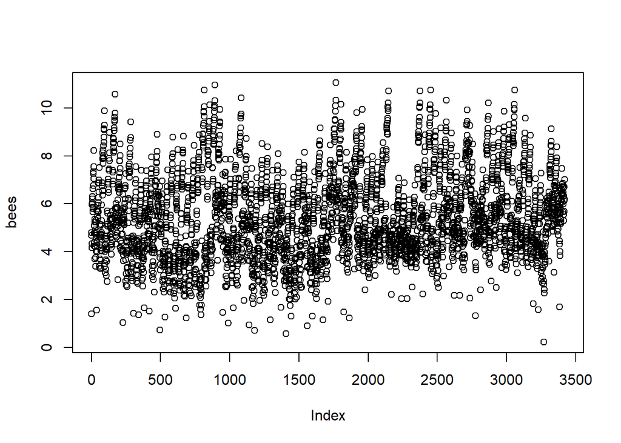

```r
#checking procrustes fit
#plot before procrustes
plot(bees)
```

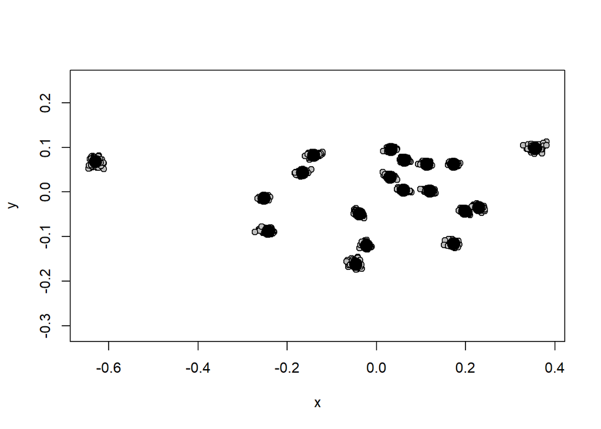

```r
#plot after procrustes
plot(beesgpa)
```

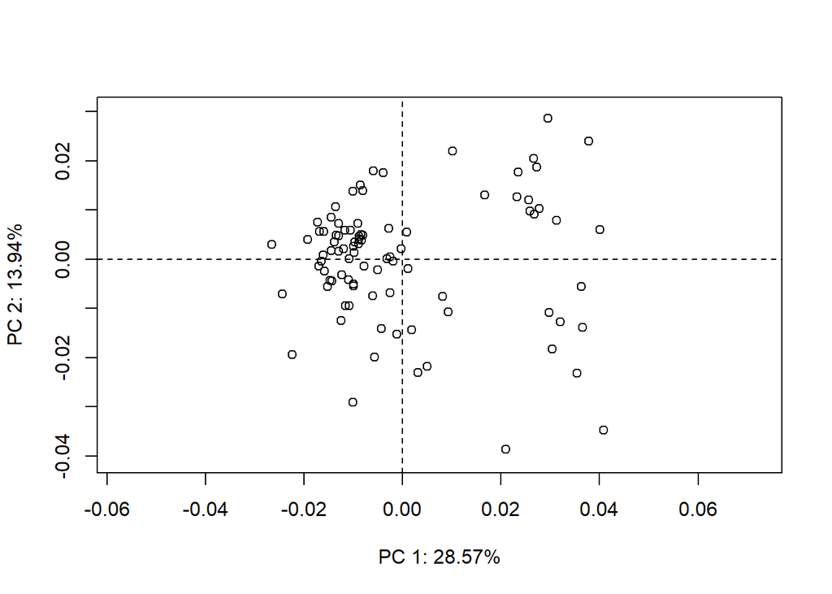

```r
#first point looks lots better now was an issue with the missing data it turns out
PCA<-gm.prcomp(beesgpa$coords)
plot(PCA)
```

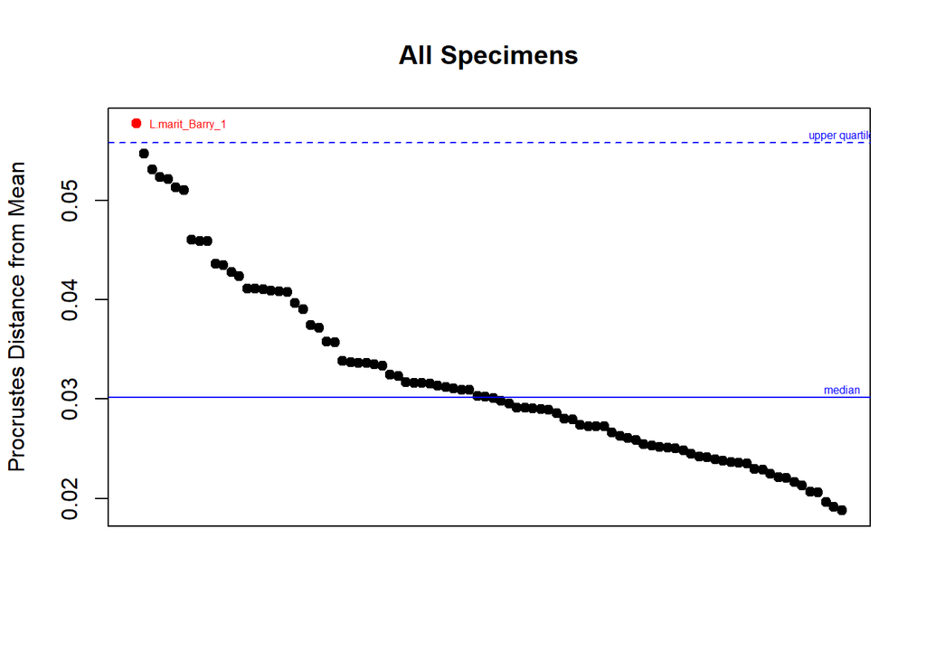

```
##               L.marit_Barry_1                    L.paahua_5
##                            58                            35
##               L.marit_Barry_5               L.marit_Barry_2
##                            62                            59
##                   L.unknown_2               L.marit_Barry_4
##                            82                            61
##             L.pekanui_Barry_2             L.hudsoni_Barry_1
##                            75                            53
## L.hukare_Barry_2_left_flipped                    L.paahua_3
##                            55                            33
##             L.pekanui_Barry_1              L.hukare_Barry_1
##                            74                            54
##                      L.fulv_5      L.unknown_3_left_flipped
##                            15                            83
##                     L.pango_5               L.marit_Barry_3
##                            40                            60
##                      L.fulv_2                     L.pango_4
##                            12                            39
##                   L.unknown_4                    L.paahua_1
##                            84                            31
##              L.waipou_Barry_4              L.hukare_Barry_3
##                            89                            56
##                      L.fulv_4               L.pango_Barry_3
##                            14                            71
##              L.waipou_Barry_5              L.keehua_Barry_1
##                            90                            57
##                      L.fulv_1                   L.unknown_5
##                            11                            85
##                        Vest_2                      L.fulv_3
##                            42                            13
##                  L.mont_3_new                     L.pango_3
##                             4                            38
##              L.waipou_Barry_2             L.pango_2_dunedin
##                            87                            37
##                    L.paahua_2               L.pango_Barry_4
##                            32                            72
##                     L.kanap_5                  L.imat_4_new
##                            30                            24
##                     L.kanap_1                     L.kanap_4
##                            26                            29
```

[output cut: 35 more lines]

```
##                            78                            79
##                   L.unknown_1                      L.huak_1
##                            81                            16
##                 L.huak_1Angie                      L.huak_2
##                            51                            17
##                      L.bolt_4             L.pango_1_dunedin
##                             1                            36
##                      L.mont_2                      L.bolt_3
##                             3                             9
##                L.bolt_Barry_4               L.pango_Barry_2
##                            49                            70
##                      L.bolt_5                     L.metal_1
##                            10                            63
##                      L.bolt_2                    L.metal_3a
##                             8                            66
```

```r
plotOutliers(beesgpa$coords)
```

```r
#plot with legend
PCaxis<-as.data.frame(PCA$x[,1:2])
PCaxis<-rownames_to_column(PCaxis,var='ID')
PCaxis$bee_species<-gsub('_.*','',PCaxis$ID)

#set colours
as.character(unique(PCaxis$bee_species))
```

```
##  [1] "L.bolt"    "L.mont"    "L.fulv"    "L.huak"    "L.imat"    "L.kanap"
##  [7] "L.paahua"  "L.pango"   "Vest"      "L.hudsoni" "L.hukare"  "L.keehua"
## [13] "L.marit"   "L.metal"   "L.pekanui" "L.purp"    "L.unknown" "L.waipou"
```

```r
#18 species
#original colours
#col<-as.character(c("dodgerblue2","tan1","gold1","springgreen4","orchid4","palegreen","firebrick1","cyan1","hotpink"))
col<-as.character(c("dodgerblue2","tan1","gold1","springgreen4","orchid4","palegreen","firebrick1","cyan1","hotpink",'blue4',"lightpink","coral4","cadetblue","plum1","chartreuse1","lightgoldenrodyellow","grey","lightskyblue"))
names(col)<-as.character(unique(PCaxis$bee_species))
col
```

```
##                 L.bolt                 L.mont                 L.fulv
##          "dodgerblue2"                 "tan1"                "gold1"
##                 L.huak                 L.imat                L.kanap
##         "springgreen4"              "orchid4"            "palegreen"
##               L.paahua                L.pango                   Vest
##           "firebrick1"                "cyan1"              "hotpink"
##              L.hudsoni               L.hukare               L.keehua
##                "blue4"            "lightpink"               "coral4"
##                L.marit                L.metal              L.pekanui
##            "cadetblue"                "plum1"          "chartreuse1"
##                 L.purp              L.unknown               L.waipou
## "lightgoldenrodyellow"                 "grey"         "lightskyblue"
```

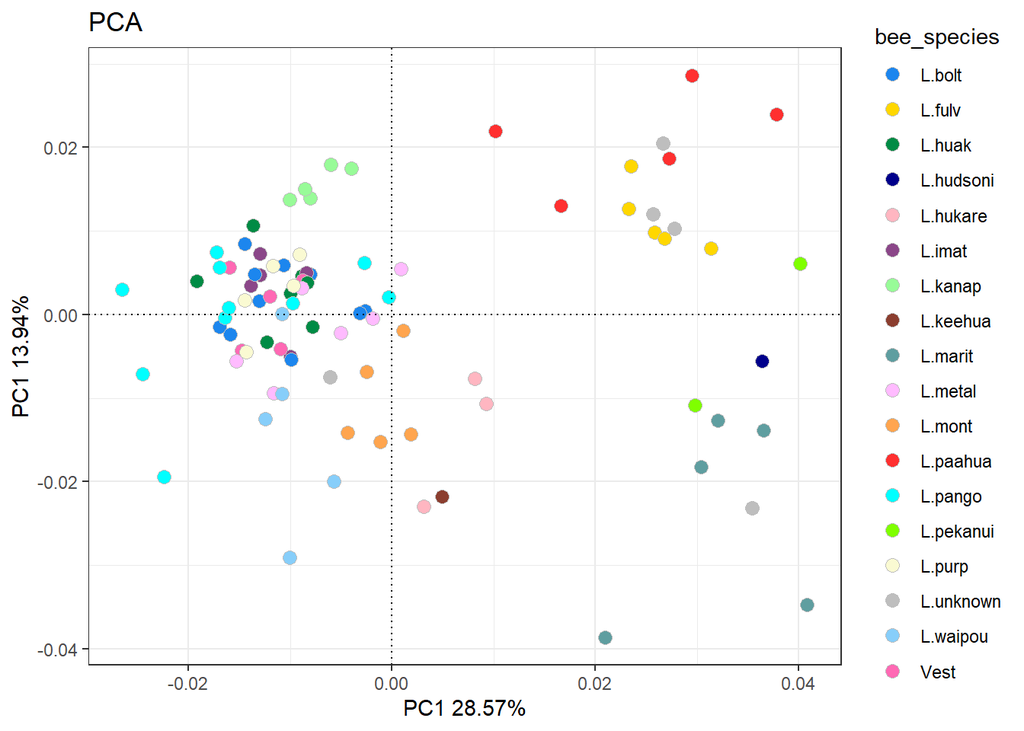

```r
#extract PC % from sdev
PC1_per<-round(as.data.frame(PCA$sdev^2/sum(PCA$sdev^2))[1,1]*100,digits=2)
PC2_per<-round(as.data.frame(PCA$sdev^2/sum(PCA$sdev^2))[2,1]*100,digits=2)
#plot
ggplot(PCaxis,aes(x=Comp1,y=Comp2,colour = bee_species))+
  geom_point(size=3,colour="grey",shape=21,aes(fill=bee_species))+
  theme_bw()+
  scale_fill_manual(values=col)+
  labs(colour='Species',x=paste0('PC1 ',PC1_per,'%'),y=paste0('PC1 ',PC2_per,'%'),title="PCA")+
  geom_hline(yintercept=0, linetype='dotted', col = 'black')+
  geom_vline(xintercept=0, linetype='dotted', col = 'black')
```

```r
#
#colouring barry's ones seperatly
#set colours
PCaxis$bee_species_baz<-gsub('_[0-9].*','',PCaxis$ID)
as.character(unique(PCaxis$bee_species))
```

```
##  [1] "L.bolt"    "L.mont"    "L.fulv"    "L.huak"    "L.imat"    "L.kanap"
##  [7] "L.paahua"  "L.pango"   "Vest"      "L.hudsoni" "L.hukare"  "L.keehua"
## [13] "L.marit"   "L.metal"   "L.pekanui" "L.purp"    "L.unknown" "L.waipou"
```

```r
as.character(unique(PCaxis$bee_species_baz))
```

```
##  [1] "L.bolt"          "L.mont"          "L.fulv"          "L.huak"
##  [5] "L.imat"          "L.kanap"         "L.paahua"        "L.pango"
##  [9] "Vest"            "L.bolt_Barry"    "L.hudsoni_Barry" "L.hukare_Barry"
## [13] "L.keehua_Barry"  "L.marit_Barry"   "L.metal"         "L.pango_Barry"
## [17] "L.pekanui_Barry" "L.purp_Barry"    "L.unknown"       "L.waipou_Barry"
```

```r
#20 species
col_baz<-as.character(c("dodgerblue2","tan1","gold1","springgreen4","orchid4","palegreen","firebrick1","cyan1","hotpink",'blue4',"lightpink","coral4","tomato","cadetblue","plum1","burlywood","chartreuse1","lightgoldenrodyellow","grey","lightskyblue"))
names(col_baz)<-as.character(unique(PCaxis$bee_species_baz))
col_baz
```

```
##                 L.bolt                 L.mont                 L.fulv
##          "dodgerblue2"                 "tan1"                "gold1"
##                 L.huak                 L.imat                L.kanap
##         "springgreen4"              "orchid4"            "palegreen"
##               L.paahua                L.pango                   Vest
##           "firebrick1"                "cyan1"              "hotpink"
##           L.bolt_Barry        L.hudsoni_Barry         L.hukare_Barry
##                "blue4"            "lightpink"               "coral4"
##         L.keehua_Barry          L.marit_Barry                L.metal
##               "tomato"            "cadetblue"                "plum1"
##          L.pango_Barry        L.pekanui_Barry           L.purp_Barry
##            "burlywood"          "chartreuse1" "lightgoldenrodyellow"
##              L.unknown         L.waipou_Barry
##                 "grey"         "lightskyblue"
```

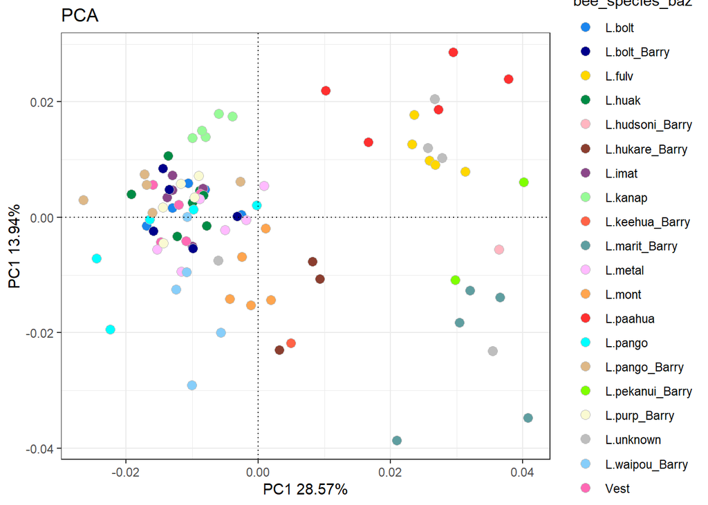

```r
#plot
ggplot(PCaxis,aes(x=Comp1,y=Comp2,colour = bee_species))+
  geom_point(size=3,colour="grey",shape=21,aes(fill=bee_species_baz))+
  theme_bw()+
  scale_fill_manual(values=col_baz)+
  labs(colour='Species',x=paste0('PC1 ',PC1_per,'%'),y=paste0('PC1 ',PC2_per,'%'),title="PCA")+
  geom_hline(yintercept=0, linetype='dotted', col = 'black')+
  geom_vline(xintercept=0, linetype='dotted', col = 'black')
```

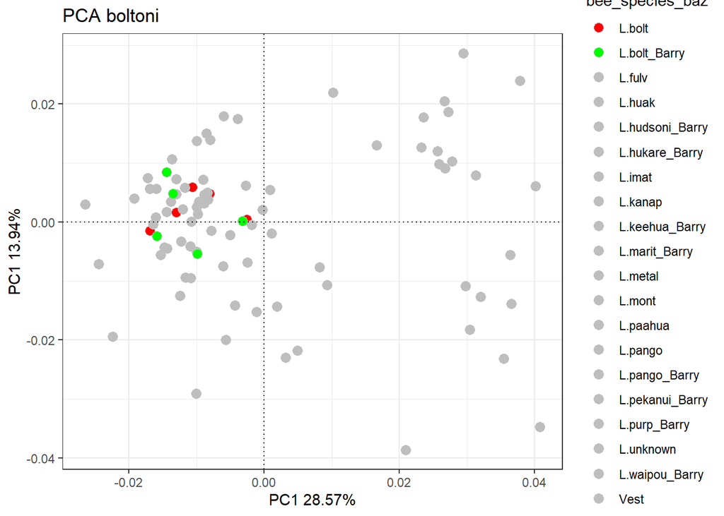

```r
#gods it confusing just comparing barrys to sams
#boltoni
col_one<-as.character(ifelse(unique(PCaxis$bee_species_baz) == 'L.bolt','red','grey'))
names(col_one)<-as.character(unique(PCaxis$bee_species_baz))
col_one<-replace(col_one, 'L.bolt_Barry', 'green')
#plot
ggplot(PCaxis,aes(x=Comp1,y=Comp2,colour = bee_species))+
  geom_point(size=3,colour="grey",shape=21,aes(fill=bee_species_baz))+
  theme_bw()+
  scale_fill_manual(values=col_one)+
  labs(colour='Species',x=paste0('PC1 ',PC1_per,'%'),y=paste0('PC1 ',PC2_per,'%'),title="PCA boltoni")+
  geom_hline(yintercept=0, linetype='dotted', col = 'black')+
  geom_vline(xintercept=0, linetype='dotted', col = 'black')
```

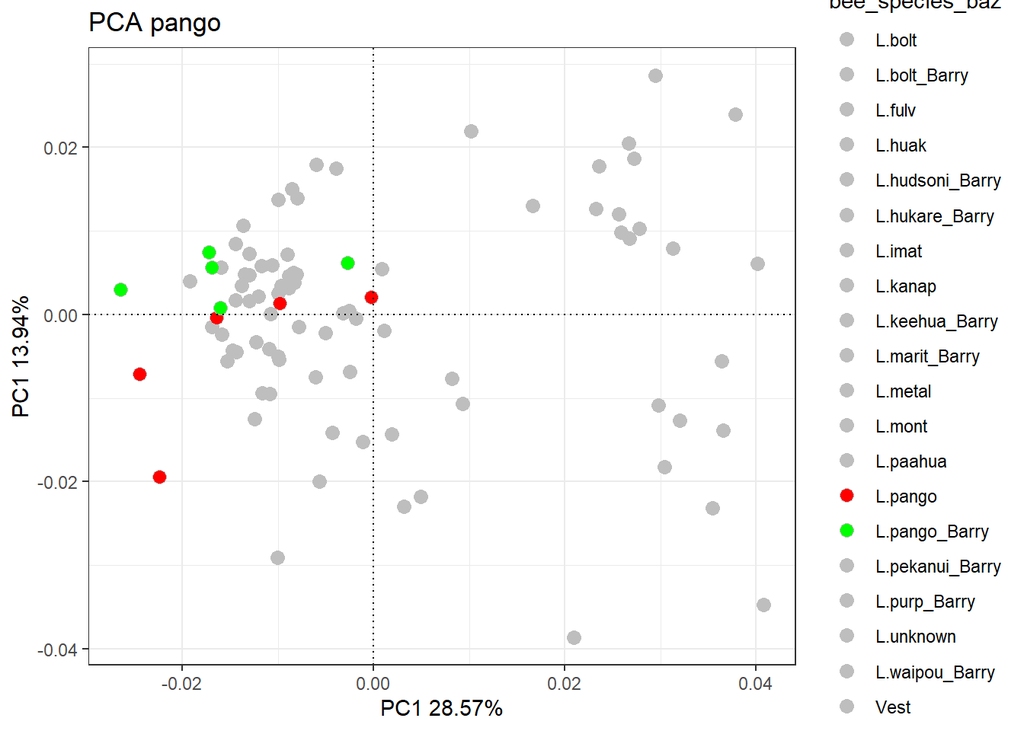

```r
#pango
col_one<-as.character(ifelse(unique(PCaxis$bee_species_baz) == 'L.pango','red','grey'))
names(col_one)<-as.character(unique(PCaxis$bee_species_baz))
col_one<-replace(col_one, 'L.pango_Barry', 'green')
#plot
ggplot(PCaxis,aes(x=Comp1,y=Comp2,colour = bee_species))+
  geom_point(size=3,colour="grey",shape=21,aes(fill=bee_species_baz))+
  theme_bw()+
  scale_fill_manual(values=col_one)+
  labs(colour='Species',x=paste0('PC1 ',PC1_per,'%'),y=paste0('PC1 ',PC2_per,'%'),title="PCA pango")+
  geom_hline(yintercept=0, linetype='dotted', col = 'black')+
  geom_vline(xintercept=0, linetype='dotted', col = 'black')
```

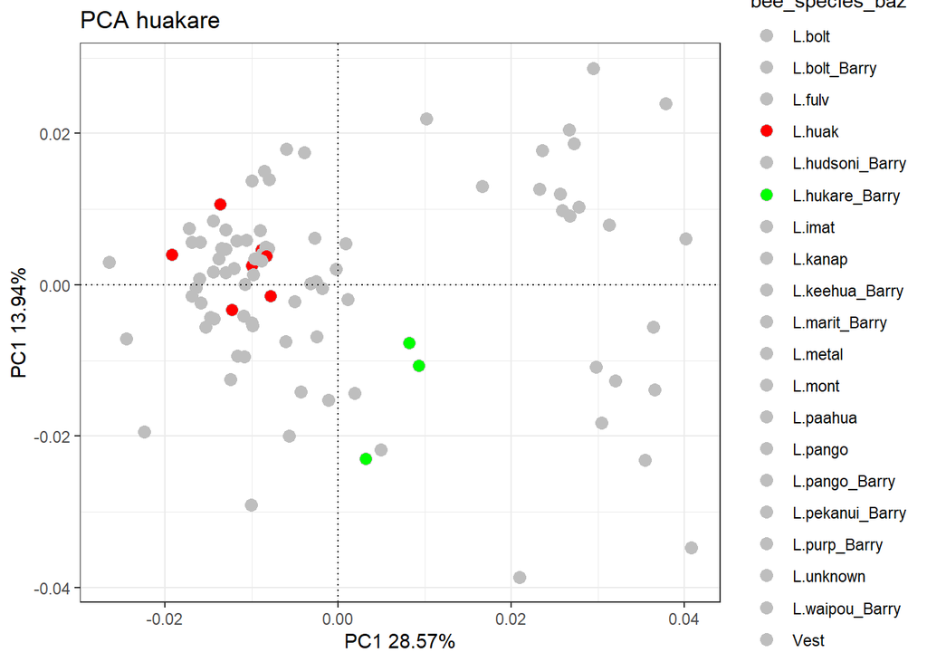

```r
#hukare
col_one<-as.character(ifelse(unique(PCaxis$bee_species_baz) == 'L.huak','red','grey'))
names(col_one)<-as.character(unique(PCaxis$bee_species_baz))
col_one<-replace(col_one, 'L.hukare_Barry', 'green')
#plot
ggplot(PCaxis,aes(x=Comp1,y=Comp2,colour = bee_species))+
  geom_point(size=3,colour="grey",shape=21,aes(fill=bee_species_baz))+
  theme_bw()+
  scale_fill_manual(values=col_one)+
  labs(colour='Species',x=paste0('PC1 ',PC1_per,'%'),y=paste0('PC1 ',PC2_per,'%'),title="PCA huakare")+
  geom_hline(yintercept=0, linetype='dotted', col = 'black')+
  geom_vline(xintercept=0, linetype='dotted', col = 'black')
```

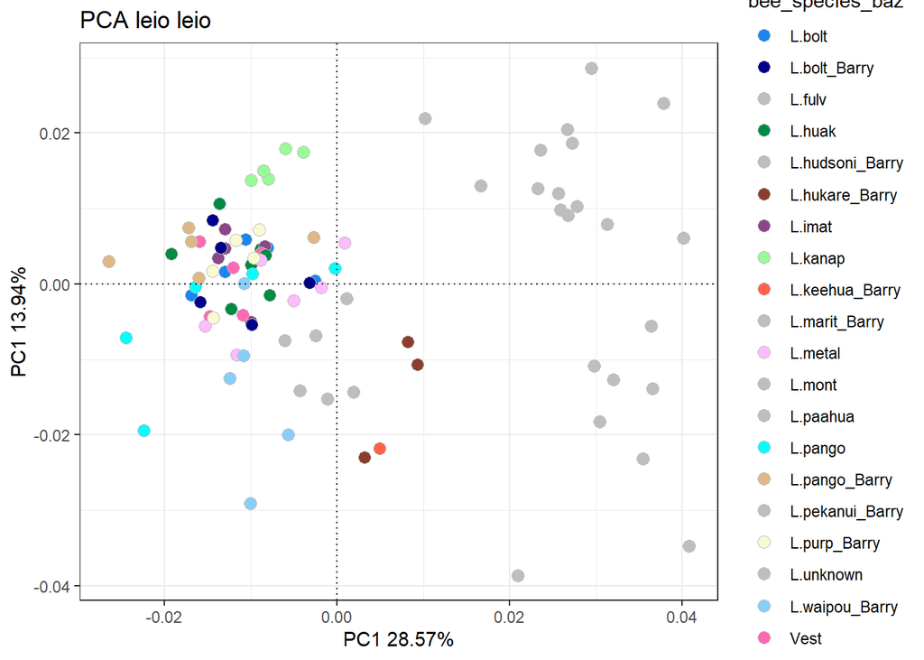

```r
#Leioproctus leioproctus
col_leio<-col_baz
col_leio<-replace(col_leio, 'L.fulv', 'grey')
col_leio<-replace(col_leio, 'L.paahua', 'grey')
col_leio<-replace(col_leio, 'L.marit_Barry', 'grey')
col_leio<-replace(col_leio, 'L.pekanui_Barry', 'grey')
col_leio<-replace(col_leio, 'L.mont', 'grey')
col_leio<-replace(col_leio, 'L.hudsoni_Barry', 'grey')
#shifting some colours around to make it easier to see
#plot
ggplot(PCaxis,aes(x=Comp1,y=Comp2,colour = bee_species))+
  geom_point(size=3,colour="grey",shape=21,aes(fill=bee_species_baz))+
  theme_bw()+
  scale_fill_manual(values=col_leio)+
  labs(colour='Species',x=paste0('PC1 ',PC1_per,'%'),y=paste0('PC1 ',PC2_per,'%'),title="PCA leio leio")+
  geom_hline(yintercept=0, linetype='dotted', col = 'black')+
  geom_vline(xintercept=0, linetype='dotted', col = 'black')
```

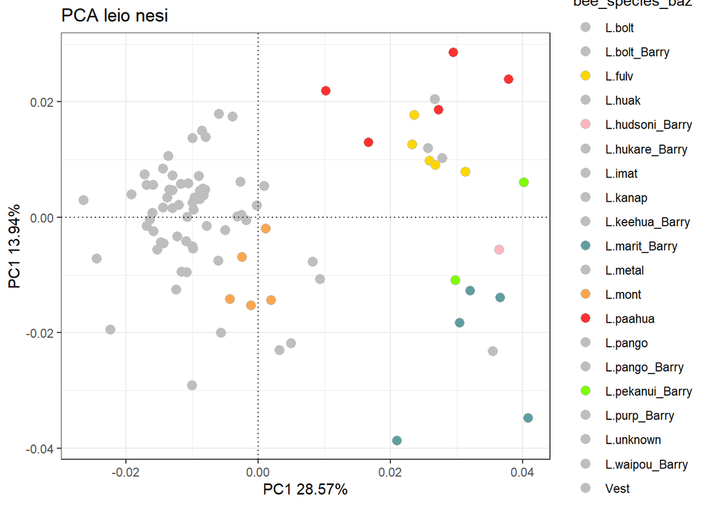

```r
#leioproctus nesocolletes
col_neso<-col_baz
col_neso<-replace(col_neso, 'L.keehua_Barry', 'grey')
col_neso<-replace(col_neso, 'L.metal', 'grey')
col_neso<-replace(col_neso, 'L.imat', 'grey')
col_neso<-replace(col_neso, 'L.purp_Barry', 'grey')
col_neso<-replace(col_neso, 'Vest', 'grey')
col_neso<-replace(col_neso, 'L.kanap', 'grey')
col_neso<-replace(col_neso, 'L.waipou_Barry', 'grey')
col_neso<-replace(col_neso, 'L.bolt', 'grey')
col_neso<-replace(col_neso, 'L.bolt_Barry', 'grey')
col_neso<-replace(col_neso, 'L.pango', 'grey')
col_neso<-replace(col_neso, 'L.pango_Barry', 'grey')
col_neso<-replace(col_neso, 'L.huak', 'grey')
col_neso<-replace(col_neso, 'L.hukare_Barry', 'grey')
#shifting some colours around to make it easier to see
#plot
ggplot(PCaxis,aes(x=Comp1,y=Comp2,colour = bee_species))+
  geom_point(size=3,colour="grey",shape=21,aes(fill=bee_species_baz))+
  theme_bw()+
  scale_fill_manual(values=col_neso)+
  labs(colour='Species',x=paste0('PC1 ',PC1_per,'%'),y=paste0('PC1 ',PC2_per,'%'),title="PCA leio nesi")+
  geom_hline(yintercept=0, linetype='dotted', col = 'black')+
  geom_vline(xintercept=0, linetype='dotted', col = 'black')
```

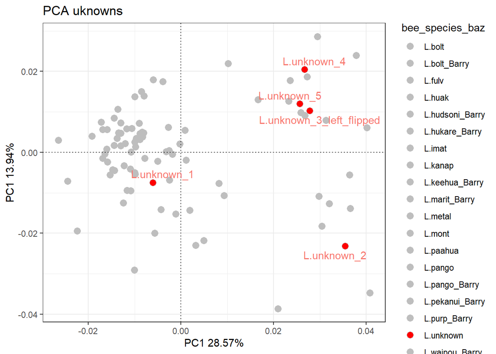

```r
#having a look at sams unknowns
col_one<-as.character(ifelse(unique(PCaxis$bee_species_baz) == 'L.unknown','red','grey'))
#col_one
names(col_one)<-as.character(unique(PCaxis$bee_species_baz))
#plot
ggplot(PCaxis,aes(x=Comp1,y=Comp2,colour = bee_species))+
  geom_point(size=3,colour="grey",shape=21,aes(fill=bee_species_baz))+
  theme_bw()+
  scale_fill_manual(values=col_one)+
  labs(colour='Species',x=paste0('PC1 ',PC1_per,'%'),y=paste0('PC1 ',PC2_per,'%'),title="PCA uknowns")+
  geom_hline(yintercept=0, linetype='dotted', col = 'black')+
  geom_vline(xintercept=0, linetype='dotted', col = 'black')+
  geom_text_repel(data=subset(PCaxis, bee_species_baz == 'L.unknown'),
            aes(x=Comp1,y=Comp2,label=ID))
```

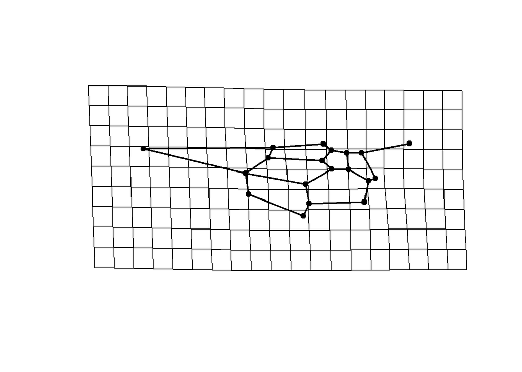

```r
#shape extremes in PCA
#bring in links file for plotting
bee_links<-read.table('C:/Users/hrlexd/Dropbox/PlantAndFood (1)/NativeBees/Bee_pictures/Sam_april/Forewing/links_all_landmarks_sam.txt',sep=',',header=F)
#find mean shape
M<-mshape(beesgpa$coord)
#find extremes of PC1 (max/min)
PC<-PCA$x[,1]
preds<-shape.predictor(beesgpa$coords,x=PC,Intercept=F,pred1=min(PC),pred2=max(PC))
#PC1 min
plotRefToTarget(M,preds$pred1,links=bee_links)
```

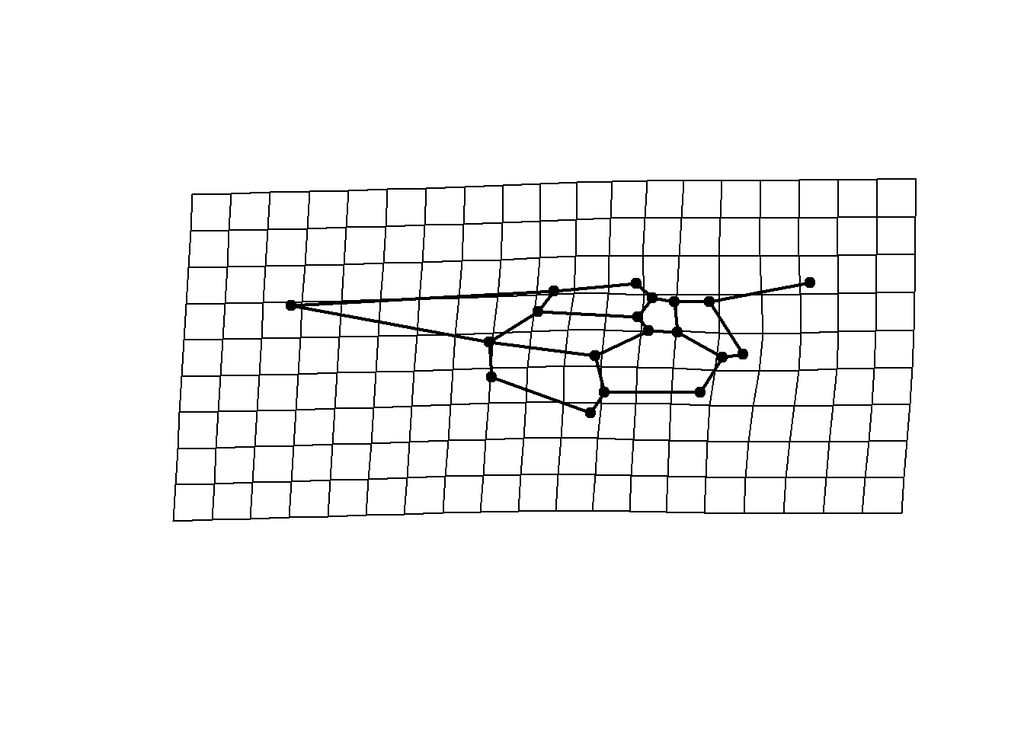

```r
#PC1 max
plotRefToTarget(M,preds$pred2,links=bee_links)
```

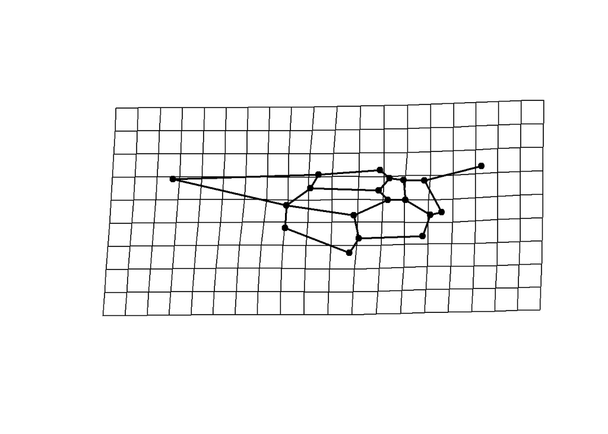

```r
PC<-PCA$x[,2]
preds<-shape.predictor(beesgpa$coords,x=PC,Intercept=F,pred1=min(PC),pred2=max(PC))
#PC2 min
plotRefToTarget(M,preds$pred1,links=bee_links)
```

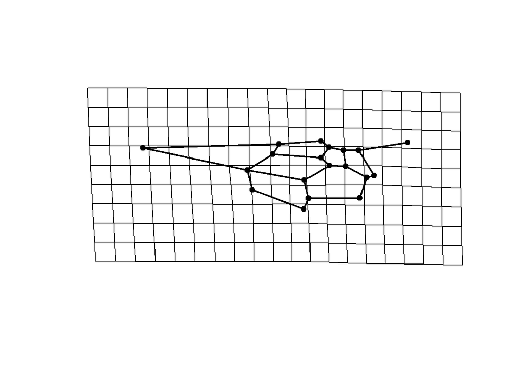

```r
#PC2 max
plotRefToTarget(M,preds$pred2,links=bee_links)
```

## Dropping first point to match other bee analyses

It actually looks much better now with point 1 in so should do it with and without now

```r
bees_removefirst <- bees[-1,,]
beesgpa<-gpagen(bees_removefirst)
```

```
##
## Performing GPA
##   |                                                                              |                                                                      |   0%  |                                                                              |==================                                       …
##
## Making projections... Finished!
```

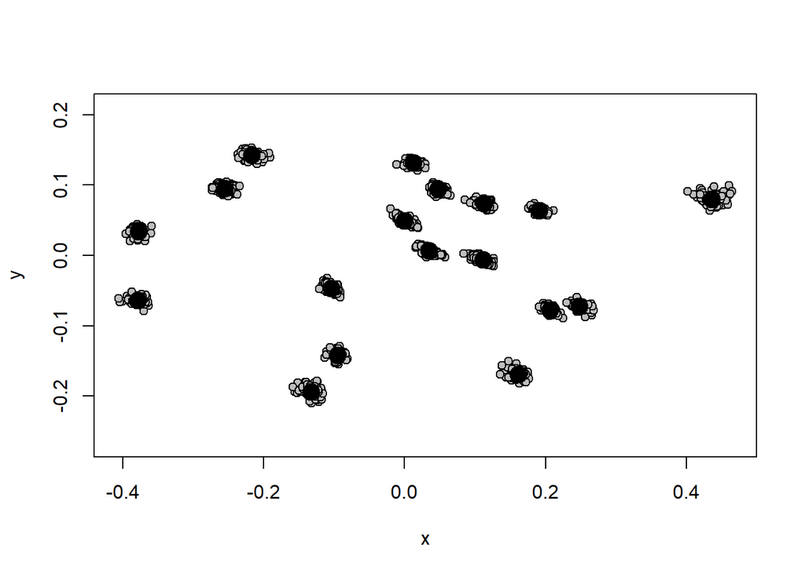

```r
#looks more stable
plot(beesgpa)
```

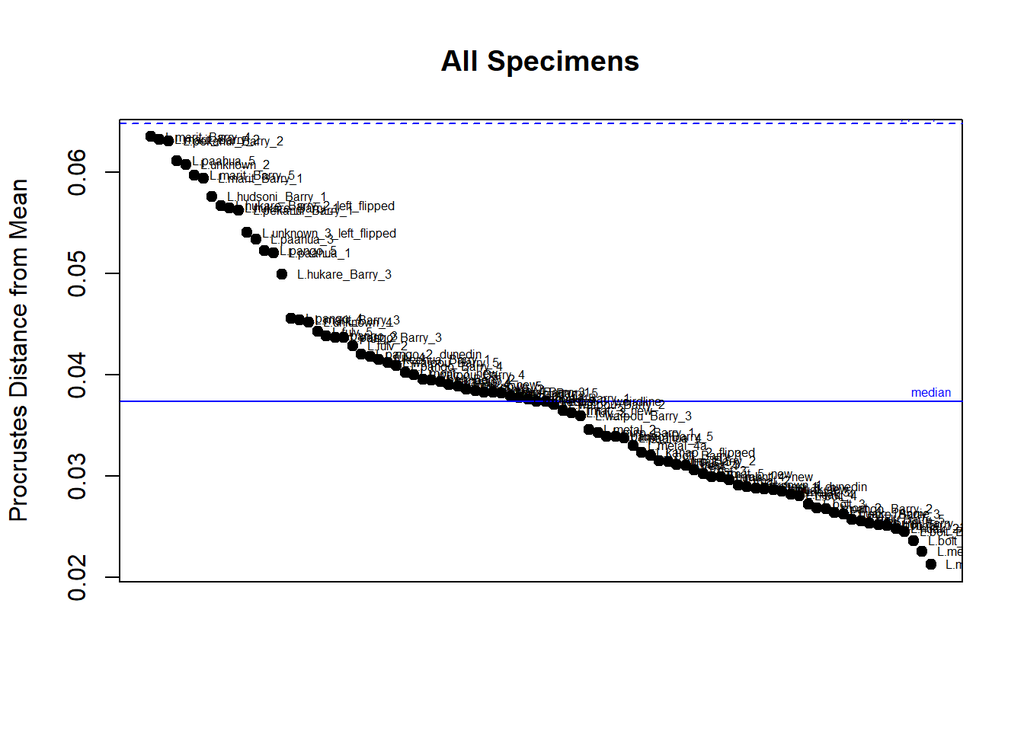

```
##               L.marit_Barry_4               L.marit_Barry_2
##                            61                            59
##             L.pekanui_Barry_2                    L.paahua_5
##                            75                            35
##                   L.unknown_2               L.marit_Barry_5
##                            82                            62
##               L.marit_Barry_1             L.hudsoni_Barry_1
##                            58                            53
## L.hukare_Barry_2_left_flipped              L.hukare_Barry_1
##                            55                            54
##             L.pekanui_Barry_1      L.unknown_3_left_flipped
##                            74                            83
##                    L.paahua_3                     L.pango_5
##                            33                            40
##                    L.paahua_1              L.hukare_Barry_3
##                            31                            56
##                     L.pango_4               L.marit_Barry_3
##                            39                            60
##                   L.unknown_4                      L.fulv_5
##                            84                            15
##                     L.pango_3               L.pango_Barry_3
##                            38                            71
##                        Vest_2                      L.fulv_2
##                            42                            12
##             L.pango_2_dunedin                      L.fulv_4
##                            37                            14
##              L.keehua_Barry_1              L.waipou_Barry_5
##                            57                            90
##               L.pango_Barry_4                  L.mont_3_new
##                            72                             4
##              L.waipou_Barry_4                L.bolt_Barry_2
##                            89                            47
##                     L.kanap_5                     L.kanap_4
##                            30                            29
##                  L.imat_4_new                   L.unknown_5
##                            24                            85
##                    L.paahua_2                     L.kanap_1
##                            32                            26
##               L.pango_Barry_1                L.bolt_Barry_3
##                            69                            48
```

[output cut: 35 more lines]

```
##                             1                             9
##                      L.mont_2               L.pango_Barry_2
##                             3                            70
##                 L.huak_1Angie                L.purp_Barry_3
##                            51                            78
##                L.bolt_Barry_5                        Vest_1
##                            50                            41
##                L.purp_Barry_4                      L.bolt_5
##                            79                            10
##                      L.mont_1                 L.huak_2Angie
##                             2                            52
##                L.bolt_Barry_4                      L.bolt_2
##                            49                             8
##                    L.metal_3a                     L.metal_1
##                            66                            63
```

```r
#plot outliers
plotOutliers(beesgpa$coords)
```

```r
#run PCA analysis
PCA<-gm.prcomp(beesgpa$coords)
#plot(PCA)
#plot with legend
PCaxis<-as.data.frame(PCA$x[,1:2])
PCaxis<-rownames_to_column(PCaxis,var='ID')
PCaxis$bee_species<-gsub('_.*','',PCaxis$ID)

#set colours
as.character(unique(PCaxis$bee_species))
```

```
##  [1] "L.bolt"    "L.mont"    "L.fulv"    "L.huak"    "L.imat"    "L.kanap"
##  [7] "L.paahua"  "L.pango"   "Vest"      "L.hudsoni" "L.hukare"  "L.keehua"
## [13] "L.marit"   "L.metal"   "L.pekanui" "L.purp"    "L.unknown" "L.waipou"
```

```r
#18 species
#original colours
#col<-as.character(c("dodgerblue2","tan1","gold1","springgreen4","orchid4","palegreen","firebrick1","cyan1","hotpink"))
col<-as.character(c("dodgerblue2","tan1","gold1","springgreen4","orchid4","palegreen","firebrick1","cyan1","hotpink",'blue4',"lightpink","coral4","cadetblue","plum1","chartreuse1","lightgoldenrodyellow","grey","lightskyblue"))
names(col)<-as.character(unique(PCaxis$bee_species))
col
```

```
##                 L.bolt                 L.mont                 L.fulv
##          "dodgerblue2"                 "tan1"                "gold1"
##                 L.huak                 L.imat                L.kanap
##         "springgreen4"              "orchid4"            "palegreen"
##               L.paahua                L.pango                   Vest
##           "firebrick1"                "cyan1"              "hotpink"
##              L.hudsoni               L.hukare               L.keehua
##                "blue4"            "lightpink"               "coral4"
##                L.marit                L.metal              L.pekanui
##            "cadetblue"                "plum1"          "chartreuse1"
##                 L.purp              L.unknown               L.waipou
## "lightgoldenrodyellow"                 "grey"         "lightskyblue"
```

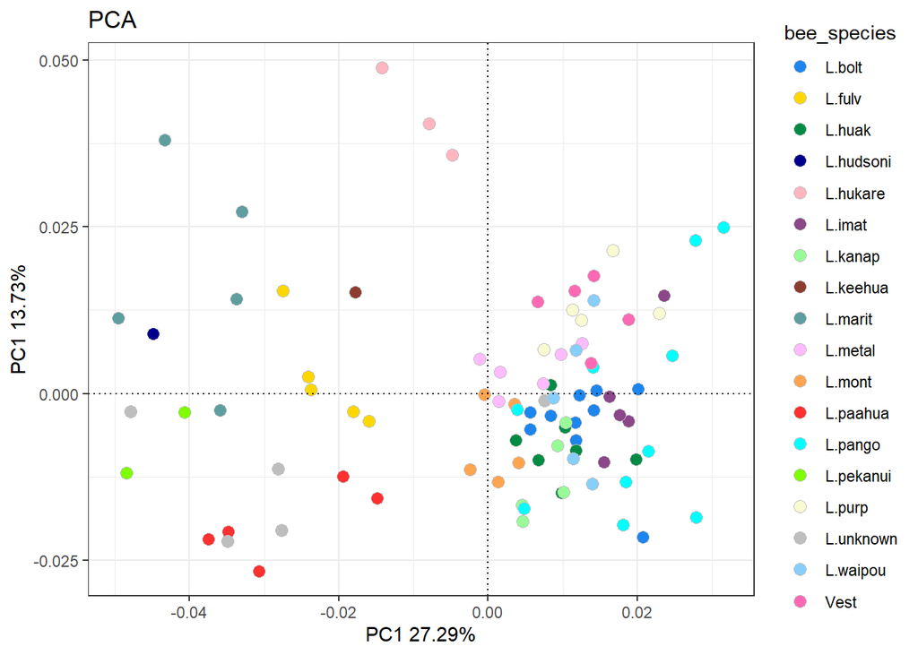

```r
#extract PC % from sdev
PC1_per<-round(as.data.frame(PCA$sdev^2/sum(PCA$sdev^2))[1,1]*100,digits=2)
PC2_per<-round(as.data.frame(PCA$sdev^2/sum(PCA$sdev^2))[2,1]*100,digits=2)
#plot
ggplot(PCaxis,aes(x=Comp1,y=Comp2,colour = bee_species))+
  geom_point(size=3,colour="grey",shape=21,aes(fill=bee_species))+
  theme_bw()+
  scale_fill_manual(values=col)+
  labs(colour='Species',x=paste0('PC1 ',PC1_per,'%'),y=paste0('PC1 ',PC2_per,'%'),title="PCA")+
  geom_hline(yintercept=0, linetype='dotted', col = 'black')+
  geom_vline(xintercept=0, linetype='dotted', col = 'black')
```

```r
#
#colouring barry's ones seperatly
#set colours
PCaxis$bee_species_baz<-gsub('_[0-9].*','',PCaxis$ID)
as.character(unique(PCaxis$bee_species))
```

```
##  [1] "L.bolt"    "L.mont"    "L.fulv"    "L.huak"    "L.imat"    "L.kanap"
##  [7] "L.paahua"  "L.pango"   "Vest"      "L.hudsoni" "L.hukare"  "L.keehua"
## [13] "L.marit"   "L.metal"   "L.pekanui" "L.purp"    "L.unknown" "L.waipou"
```

```r
as.character(unique(PCaxis$bee_species_baz))
```

```
##  [1] "L.bolt"          "L.mont"          "L.fulv"          "L.huak"
##  [5] "L.imat"          "L.kanap"         "L.paahua"        "L.pango"
##  [9] "Vest"            "L.bolt_Barry"    "L.hudsoni_Barry" "L.hukare_Barry"
## [13] "L.keehua_Barry"  "L.marit_Barry"   "L.metal"         "L.pango_Barry"
## [17] "L.pekanui_Barry" "L.purp_Barry"    "L.unknown"       "L.waipou_Barry"
```

```r
#20 species
col_baz<-as.character(c("dodgerblue2","tan1","gold1","springgreen4","orchid4","palegreen","firebrick1","cyan1","hotpink",'blue4',"lightpink","coral4","tomato","cadetblue","plum1","burlywood","chartreuse1","lightgoldenrodyellow","grey","lightskyblue"))
names(col_baz)<-as.character(unique(PCaxis$bee_species_baz))
col_baz
```

```
##                 L.bolt                 L.mont                 L.fulv
##          "dodgerblue2"                 "tan1"                "gold1"
##                 L.huak                 L.imat                L.kanap
##         "springgreen4"              "orchid4"            "palegreen"
##               L.paahua                L.pango                   Vest
##           "firebrick1"                "cyan1"              "hotpink"
##           L.bolt_Barry        L.hudsoni_Barry         L.hukare_Barry
##                "blue4"            "lightpink"               "coral4"
##         L.keehua_Barry          L.marit_Barry                L.metal
##               "tomato"            "cadetblue"                "plum1"
##          L.pango_Barry        L.pekanui_Barry           L.purp_Barry
##            "burlywood"          "chartreuse1" "lightgoldenrodyellow"
##              L.unknown         L.waipou_Barry
##                 "grey"         "lightskyblue"
```

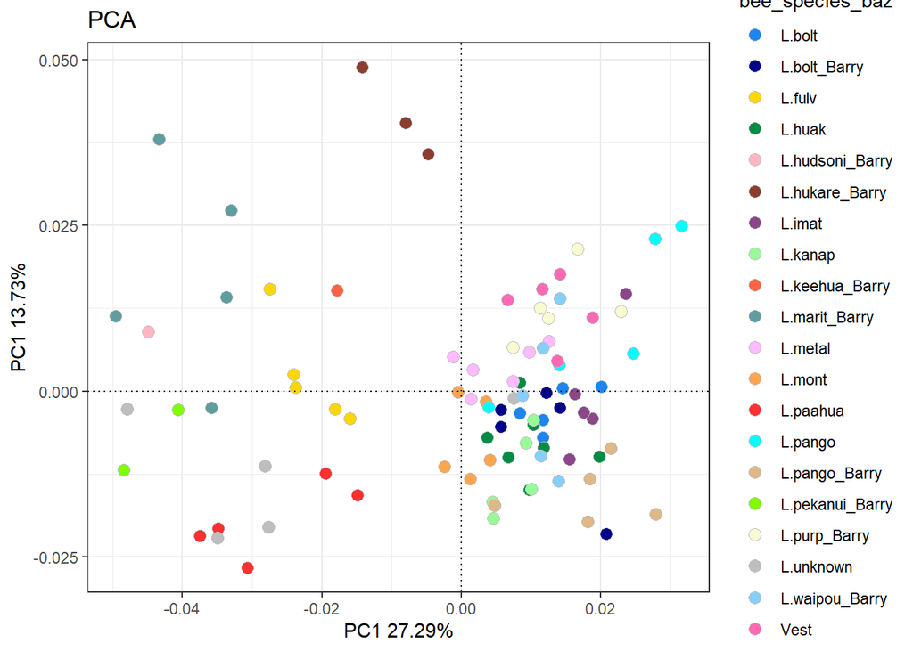

```r
#plot
ggplot(PCaxis,aes(x=Comp1,y=Comp2,colour = bee_species))+
  geom_point(size=3,colour="grey",shape=21,aes(fill=bee_species_baz))+
  theme_bw()+
  scale_fill_manual(values=col_baz)+
  labs(colour='Species',x=paste0('PC1 ',PC1_per,'%'),y=paste0('PC1 ',PC2_per,'%'),title="PCA")+
  geom_hline(yintercept=0, linetype='dotted', col = 'black')+
  geom_vline(xintercept=0, linetype='dotted', col = 'black')
```

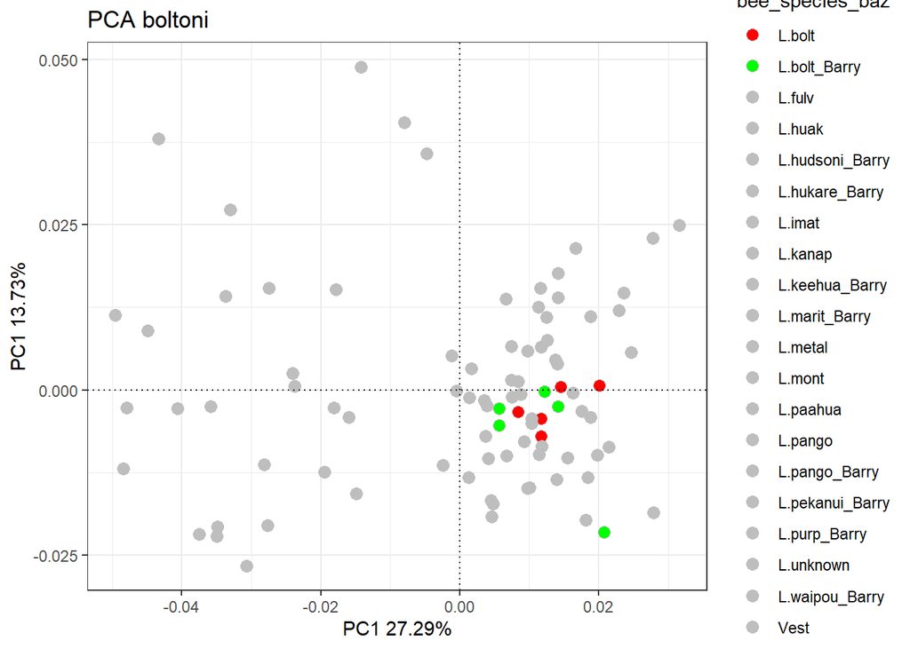

```r
#gods it confusing just comparing barrys to sams
#boltoni
col_one<-as.character(ifelse(unique(PCaxis$bee_species_baz) == 'L.bolt','red','grey'))
names(col_one)<-as.character(unique(PCaxis$bee_species_baz))
col_one<-replace(col_one, 'L.bolt_Barry', 'green')
#plot
ggplot(PCaxis,aes(x=Comp1,y=Comp2,colour = bee_species))+
  geom_point(size=3,colour="grey",shape=21,aes(fill=bee_species_baz))+
  theme_bw()+
  scale_fill_manual(values=col_one)+
  labs(colour='Species',x=paste0('PC1 ',PC1_per,'%'),y=paste0('PC1 ',PC2_per,'%'),title="PCA boltoni")+
  geom_hline(yintercept=0, linetype='dotted', col = 'black')+
  geom_vline(xintercept=0, linetype='dotted', col = 'black')
```

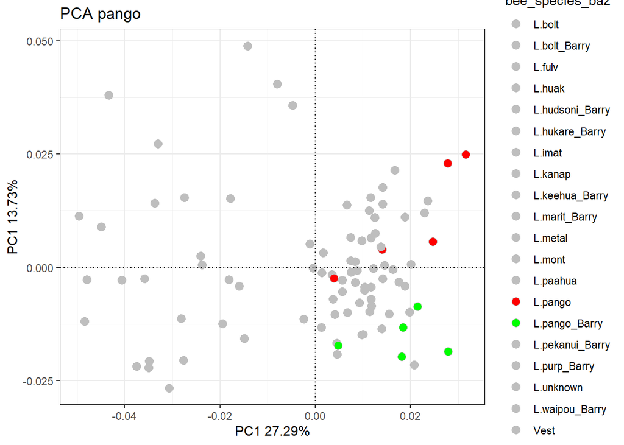

```r
#pango
col_one<-as.character(ifelse(unique(PCaxis$bee_species_baz) == 'L.pango','red','grey'))
names(col_one)<-as.character(unique(PCaxis$bee_species_baz))
col_one<-replace(col_one, 'L.pango_Barry', 'green')
#plot
ggplot(PCaxis,aes(x=Comp1,y=Comp2,colour = bee_species))+
  geom_point(size=3,colour="grey",shape=21,aes(fill=bee_species_baz))+
  theme_bw()+
  scale_fill_manual(values=col_one)+
  labs(colour='Species',x=paste0('PC1 ',PC1_per,'%'),y=paste0('PC1 ',PC2_per,'%'),title="PCA pango")+
  geom_hline(yintercept=0, linetype='dotted', col = 'black')+
  geom_vline(xintercept=0, linetype='dotted', col = 'black')
```

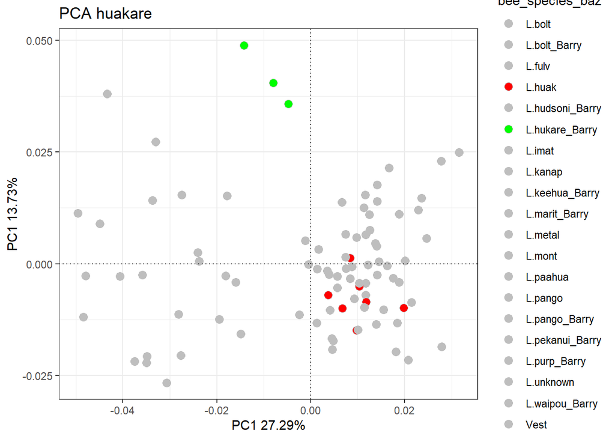

```r
#hukare
col_one<-as.character(ifelse(unique(PCaxis$bee_species_baz) == 'L.huak','red','grey'))
names(col_one)<-as.character(unique(PCaxis$bee_species_baz))
col_one<-replace(col_one, 'L.hukare_Barry', 'green')
#plot
ggplot(PCaxis,aes(x=Comp1,y=Comp2,colour = bee_species))+
  geom_point(size=3,colour="grey",shape=21,aes(fill=bee_species_baz))+
  theme_bw()+
  scale_fill_manual(values=col_one)+
  labs(colour='Species',x=paste0('PC1 ',PC1_per,'%'),y=paste0('PC1 ',PC2_per,'%'),title="PCA huakare")+
  geom_hline(yintercept=0, linetype='dotted', col = 'black')+
  geom_vline(xintercept=0, linetype='dotted', col = 'black')
```

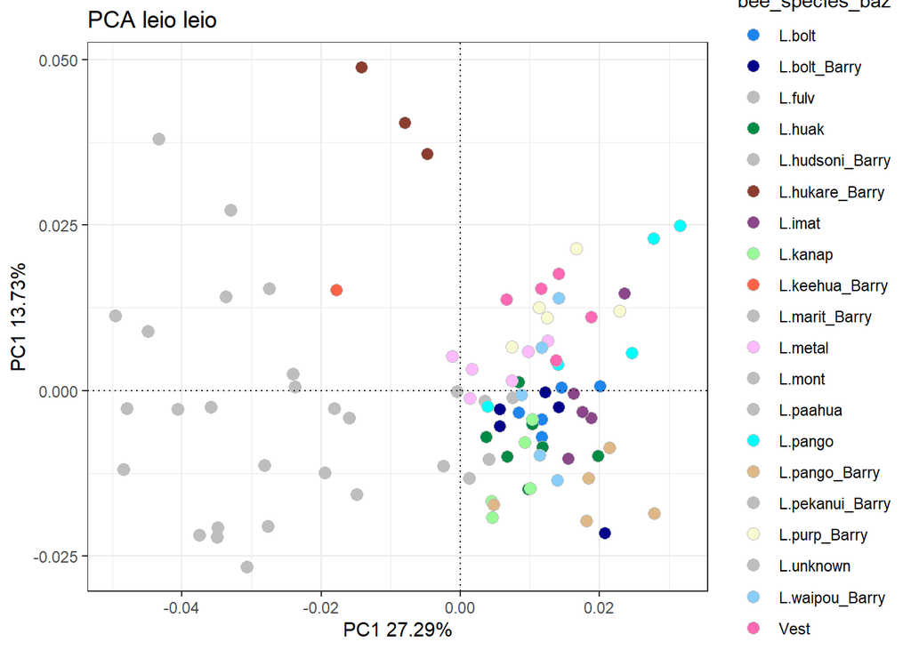

```r
#Leioproctus leioproctus
col_leio<-col_baz
col_leio<-replace(col_leio, 'L.fulv', 'grey')
col_leio<-replace(col_leio, 'L.paahua', 'grey')
col_leio<-replace(col_leio, 'L.marit_Barry', 'grey')
col_leio<-replace(col_leio, 'L.pekanui_Barry', 'grey')
col_leio<-replace(col_leio, 'L.mont', 'grey')
col_leio<-replace(col_leio, 'L.hudsoni_Barry', 'grey')
#shifting some colours around to make it easier to see
#plot
ggplot(PCaxis,aes(x=Comp1,y=Comp2,colour = bee_species))+
  geom_point(size=3,colour="grey",shape=21,aes(fill=bee_species_baz))+
  theme_bw()+
  scale_fill_manual(values=col_leio)+
  labs(colour='Species',x=paste0('PC1 ',PC1_per,'%'),y=paste0('PC1 ',PC2_per,'%'),title="PCA leio leio")+
  geom_hline(yintercept=0, linetype='dotted', col = 'black')+
  geom_vline(xintercept=0, linetype='dotted', col = 'black')
```

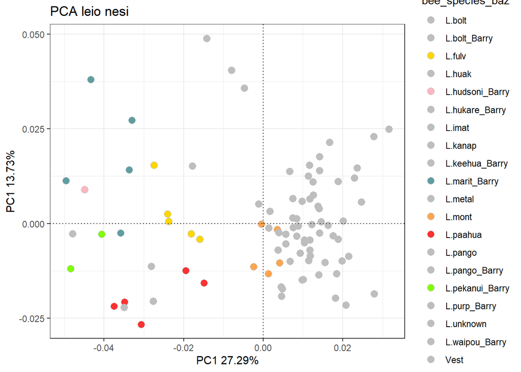

```r
#leioproctus nesocolletes
col_neso<-col_baz
col_neso<-replace(col_neso, 'L.keehua_Barry', 'grey')
col_neso<-replace(col_neso, 'L.metal', 'grey')
col_neso<-replace(col_neso, 'L.imat', 'grey')
col_neso<-replace(col_neso, 'L.purp_Barry', 'grey')
col_neso<-replace(col_neso, 'Vest', 'grey')
col_neso<-replace(col_neso, 'L.kanap', 'grey')
col_neso<-replace(col_neso, 'L.waipou_Barry', 'grey')
col_neso<-replace(col_neso, 'L.bolt', 'grey')
col_neso<-replace(col_neso, 'L.bolt_Barry', 'grey')
col_neso<-replace(col_neso, 'L.pango', 'grey')
col_neso<-replace(col_neso, 'L.pango_Barry', 'grey')
col_neso<-replace(col_neso, 'L.huak', 'grey')
col_neso<-replace(col_neso, 'L.hukare_Barry', 'grey')
#shifting some colours around to make it easier to see
#plot
ggplot(PCaxis,aes(x=Comp1,y=Comp2,colour = bee_species))+
  geom_point(size=3,colour="grey",shape=21,aes(fill=bee_species_baz))+
  theme_bw()+
  scale_fill_manual(values=col_neso)+
  labs(colour='Species',x=paste0('PC1 ',PC1_per,'%'),y=paste0('PC1 ',PC2_per,'%'),title="PCA leio nesi")+
  geom_hline(yintercept=0, linetype='dotted', col = 'black')+
  geom_vline(xintercept=0, linetype='dotted', col = 'black')
```

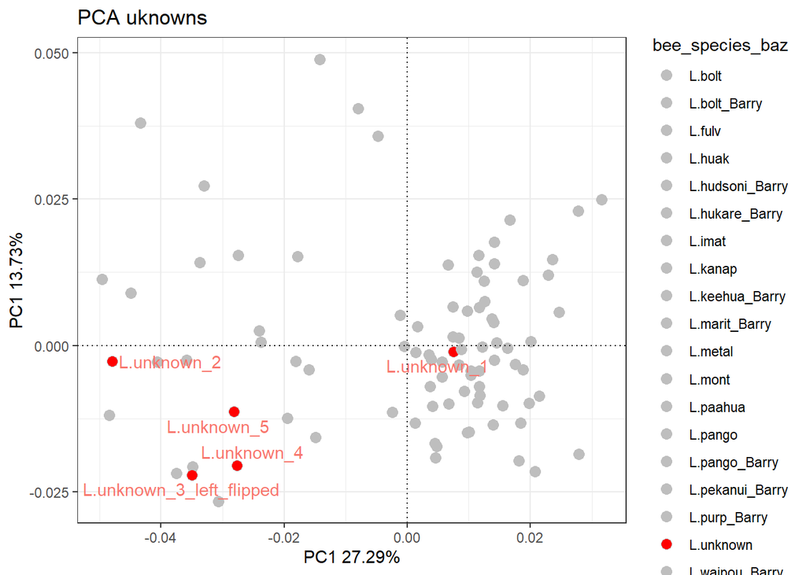

```r
#having a look at sams unknowns
col_one<-as.character(ifelse(unique(PCaxis$bee_species_baz) == 'L.unknown','red','grey'))
#col_one
names(col_one)<-as.character(unique(PCaxis$bee_species_baz))
#plot
ggplot(PCaxis,aes(x=Comp1,y=Comp2,colour = bee_species))+
  geom_point(size=3,colour="grey",shape=21,aes(fill=bee_species_baz))+
  theme_bw()+
  scale_fill_manual(values=col_one)+
  labs(colour='Species',x=paste0('PC1 ',PC1_per,'%'),y=paste0('PC1 ',PC2_per,'%'),title="PCA uknowns")+
  geom_hline(yintercept=0, linetype='dotted', col = 'black')+
  geom_vline(xintercept=0, linetype='dotted', col = 'black')+
  geom_text_repel(data=subset(PCaxis, bee_species_baz == 'L.unknown'),
            aes(x=Comp1,y=Comp2,label=ID))
```

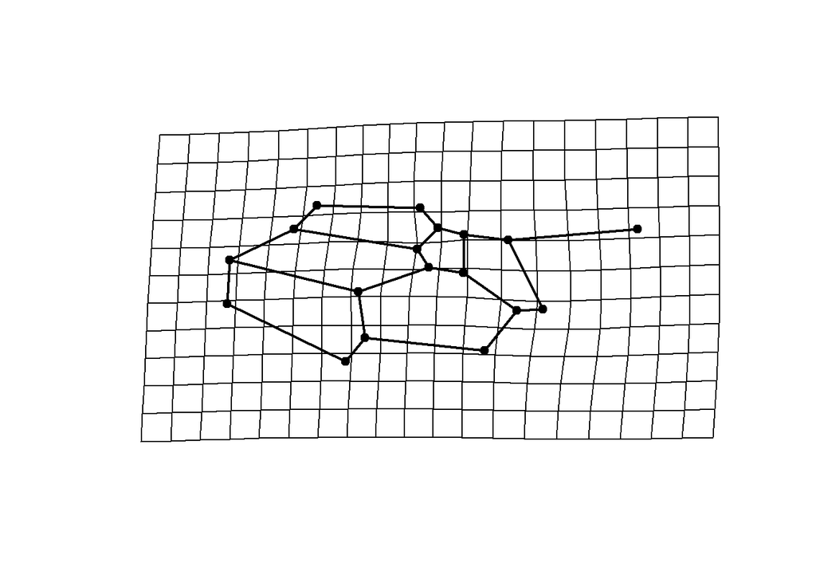

```r
#shape extremes in PCA
#bring in links file for plotting
bee_links<-read.table('C:/Users/hrlexd/Dropbox/PlantAndFood (1)/NativeBees/Bee_pictures/Sam_april/Forewing/links_all_landmarks_remove1_sam.txt',sep=',',header=F)
#find mean shape
M<-mshape(beesgpa$coord)
#find extremes of PC1 (max/min)
PC<-PCA$x[,1]
preds<-shape.predictor(beesgpa$coords,x=PC,Intercept=F,pred1=min(PC),pred2=max(PC))
#PC1 min
plotRefToTarget(M,preds$pred1,links=bee_links)
```

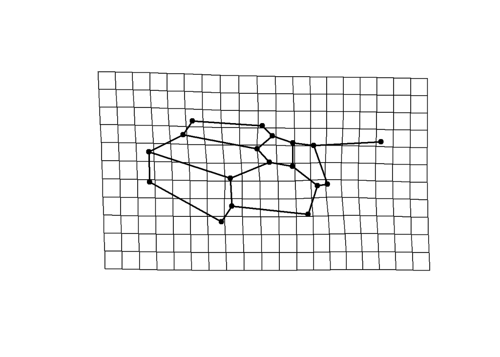

```r
#PC1 max
plotRefToTarget(M,preds$pred2,links=bee_links)
```

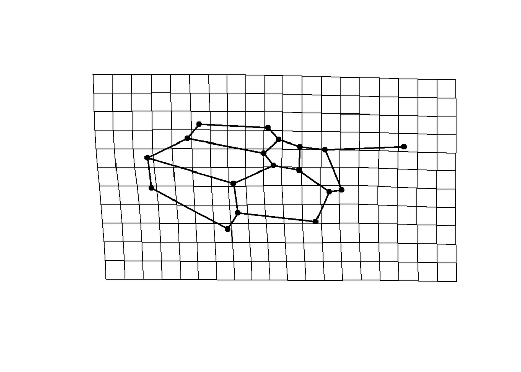

```r
PC<-PCA$x[,2]
preds<-shape.predictor(beesgpa$coords,x=PC,Intercept=F,pred1=min(PC),pred2=max(PC))
#PC2 min
plotRefToTarget(M,preds$pred1,links=bee_links)
```

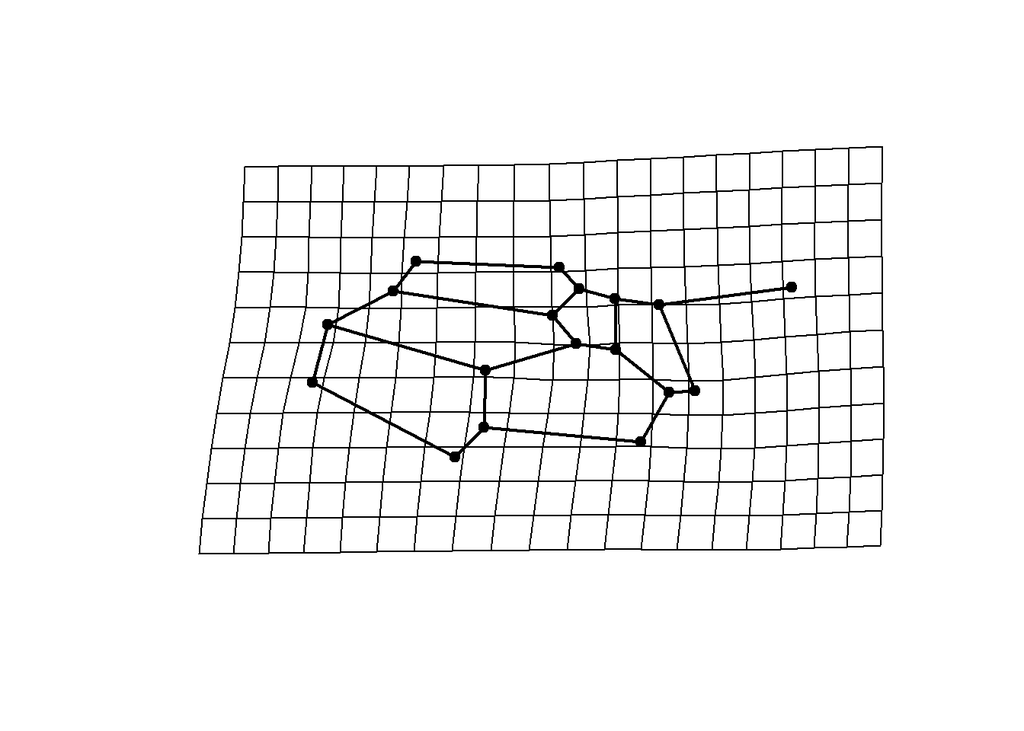

```r
#PC2 max
plotRefToTarget(M,preds$pred2,links=bee_links)
```